# Visualization

2022-11-07

## 0. 환경 설정

```r
.libPaths()
```

```
## [1] "C:/Program Files/R/R-4.2.2/library"
## [2] "C:/Users/jeffr/AppData/Local/R/win-library/4.2"
```

```r
.libPaths("C:/Program Files/R/R-4.2.2/library")
```

사용 버전 R version 4.2.2 (2022-10-31 ucrt)

```r
getwd()
```

```
## [1] "D:/R/Visualization"
```

```r
setwd("D:/R/Visualization")
```

필요 패키지 설치

```r
my_packages <- c("tidyverse", "broom", "coefplot", "cowplot",
                 "gapminder", "GGally", "ggrepel", "ggridges",
                 "gridExtra", "here", "interplot", "margins",
                 "maps", "mapproj", "mapdata", "MASS", "quantreg",
                 "rlang", "sclaes", "survey", "srvyr", "virids",
                 "viridisLite", "devtools")

# 패키지 설치 (최초 1회만 실행)
# install.packages(my_packages)
# devtools::install_github("kjhealy/socviz")
# update.packages()
```

## 1. 데이터 보기

```r
anscombe
```

```
##    x1 x2 x3 x4    y1   y2    y3    y4
## 1  10 10 10  8  8.04 9.14  7.46  6.58
## 2   8  8  8  8  6.95 8.14  6.77  5.76
## 3  13 13 13  8  7.58 8.74 12.74  7.71
## 4   9  9  9  8  8.81 8.77  7.11  8.84
## 5  11 11 11  8  8.33 9.26  7.81  8.47
## 6  14 14 14  8  9.96 8.10  8.84  7.04
## 7   6  6  6  8  7.24 6.13  6.08  5.25
## 8   4  4  4 19  4.26 3.10  5.39 12.50
## 9  12 12 12  8 10.84 9.13  8.15  5.56
## 10  7  7  7  8  4.82 7.26  6.42  7.91
## 11  5  5  5  8  5.68 4.74  5.73  6.89
```

## 2. 시작하기

## transcription

- 1. 코드 작성하기
- 2. 출력 결과 살펴보기
- 3. 메모하기

### 2.6 첫번째 그림 만들기

```r
library(gapminder)
library(tidyverse)
gapminder
```

```
## # A tibble: 1,704 × 6
##    country     continent  year lifeExp      pop gdpPercap
##    <fct>       <fct>     <int>   <dbl>    <int>     <dbl>
##  1 Afghanistan Asia       1952    28.8  8425333      779.
##  2 Afghanistan Asia       1957    30.3  9240934      821.
##  3 Afghanistan Asia       1962    32.0 10267083      853.
##  4 Afghanistan Asia       1967    34.0 11537966      836.
##  5 Afghanistan Asia       1972    36.1 13079460      740.
##  6 Afghanistan Asia       1977    38.4 14880372      786.
##  7 Afghanistan Asia       1982    39.9 12881816      978.
##  8 Afghanistan Asia       1987    40.8 13867957      852.
##  9 Afghanistan Asia       1992    41.7 16317921      649.
## 10 Afghanistan Asia       1997    41.8 22227415      635.
## # … with 1,694 more rows
```

ggplot 이용하기

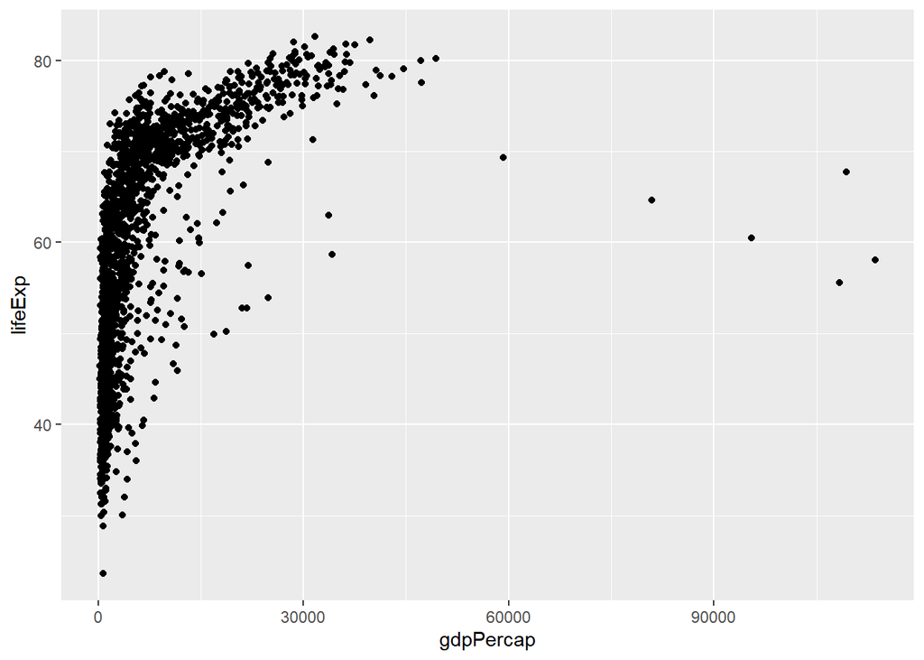

```r
p <- ggplot(data = gapminder, mapping = aes(x = gdpPercap, y = lifeExp))
p + geom_point()
```

## 3. 도표 만들기

### 3.1 ggplot의 동작 방식

- 1. 정돈된 데이터
- 2. 매핑
- 3. 형태(Geom)
- 4. 좌표계 및 척도
- 5. 레이블 및 안내선

### 3.2 깔끔한 데이터(tidy data)

도표 작성을 위한 스키마

```
p <- ggplot(data = <data>,
            mapping = aes(<aesthetic> = <variable>,
                          <aesthetic> = <variable>,
                          <...> = <...>))

p + geom_<type>(<...>) +
    scale_<mapping>_<type>(<...>) +
    coord_<type>(<...>) +
    labs(<...>)
```

### 3.3 매핑, 데이터를 시각 요소에 연결하기

1. 데이터 인식

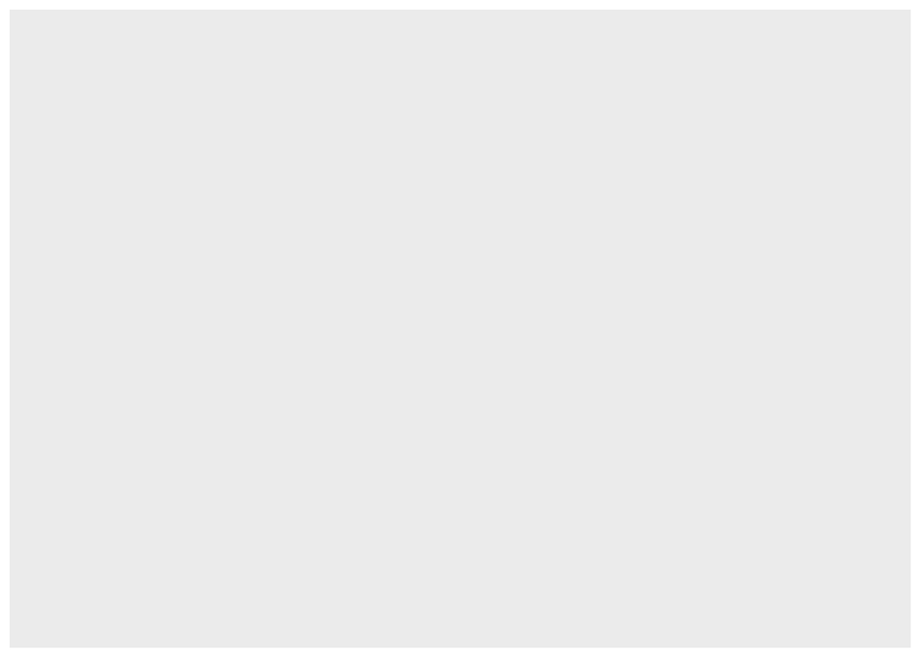

```r
p <- ggplot(data = gapminder)
p
```

2. 매핑

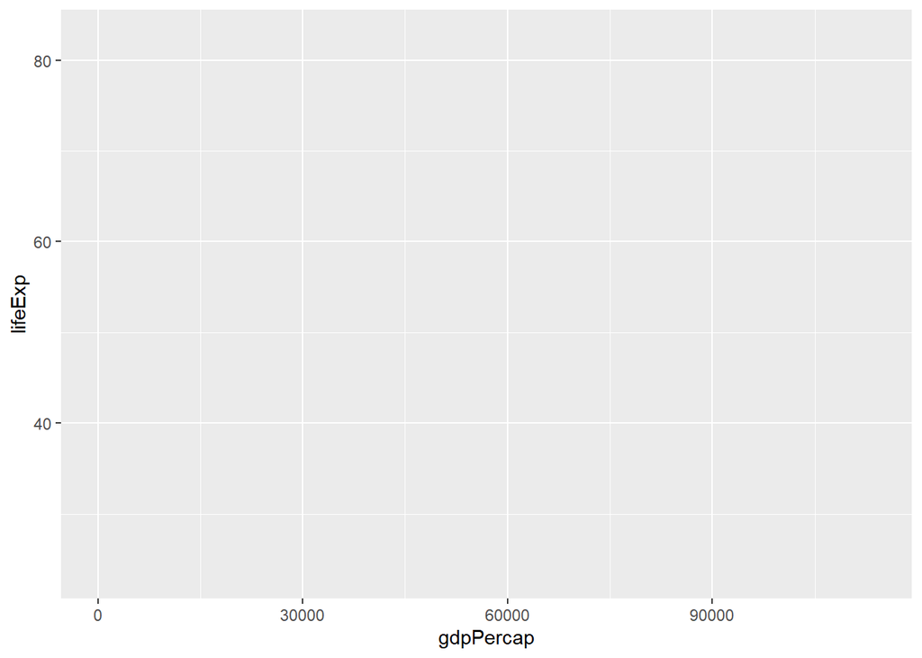

```r
p <- ggplot(data = gapminder,
            mapping = aes(x = gdpPercap,
                          y = lifeExp))

p
```

p 객체는 ggplot 함수로 생성되었고, 우리가 원하는 매핑 정보 및 기본으로 추가된 정보를 이미 담고 있다. 다만, 어떤 종류의 표를 그려야 하는지는 아직 알려주지 않았다. 산점도를 나타내라는 geom_point()를 추가한다.

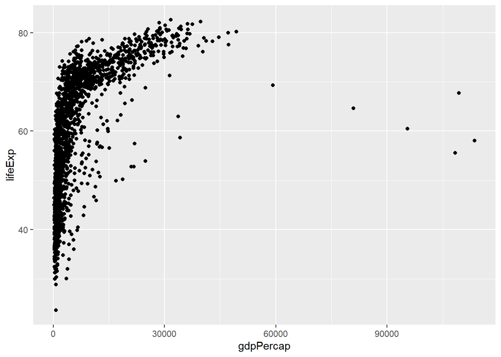

```r
p + geom_point()
```

### 3.4 레이어별로 도표 만들기

ggplot에게 무슨 일을 해야 하는지 자세히 설명하는 것을 배우게 된다. 사용할 수 있는 geom(또는 도표 유형)에 대해 더 배우고 좌표계(coordinate system)와 척도, 가이드 요소 및 도표의 테마 특성을 제어하는 함수

도표 만드는 순서

1. 데이터가 무엇인지 ggplot 함수에 알린다.
2. ggplot()에게 우리가 알고 싶은 관계를 통보한다. 편의상 처음 두 단계의 결과를 p라는 객체에 넣을 것임

```
   p <- ggplot(data = , mapping = )
```

3. 데이터 간의 관계를 어떤 방식으로 보고 싶은지 ggplot에게 알린다.
4. 필요에 따라 geom 객체에 레이어를 쌓고 한 번에 하나씩 p 객체에 추가한다.

```
  p + geom_<type>
```

5. 몇 가지 추가 함수를 사용해 척도, 레이블, 눈금, 제목을 조정한다.

위와 같이 사용하면, 그래프의 종류를 변경하는 일이 용이해질 것임

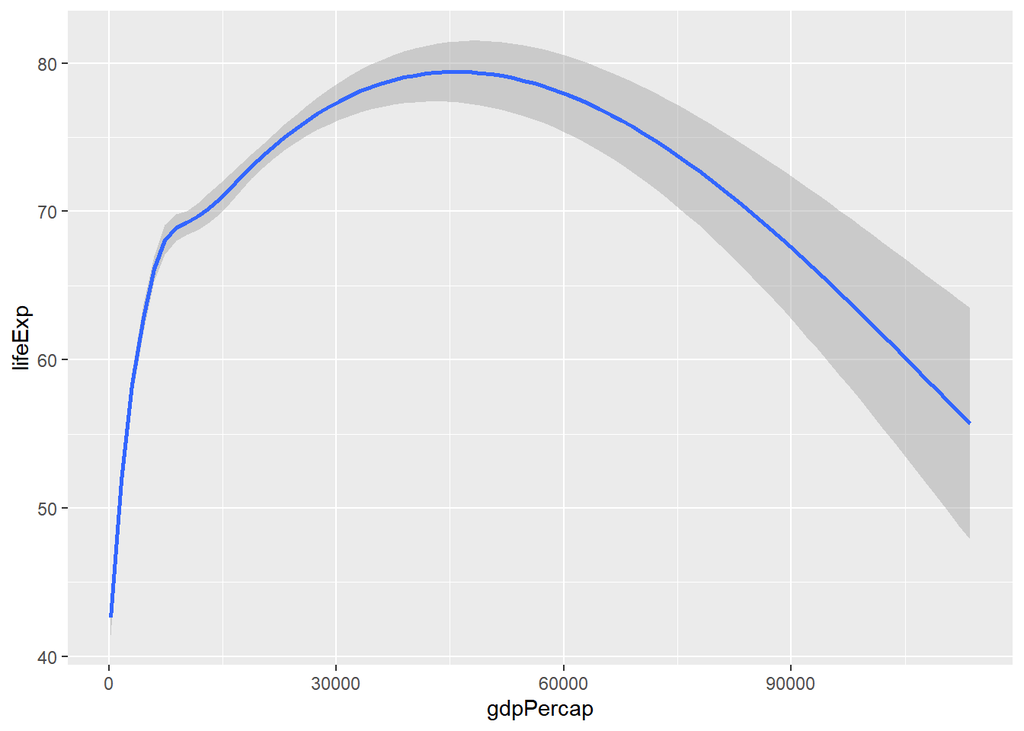

```r
# 추세선을 사용한 GDP 대비 기대수명 도표
p + geom_smooth()
```

콘솔 메시지 R은 geom_smooth() 함수가 gam이라는 메서드 method를 사용하고 있음을 알려줌 이 경우 일반화 가법 모형(generalized additive model)에 적합하다는 의미를 나타냄

이때 대신 사용할 수 있는 방법이 있음을 암시함 method의 인수를 바꿔보자.

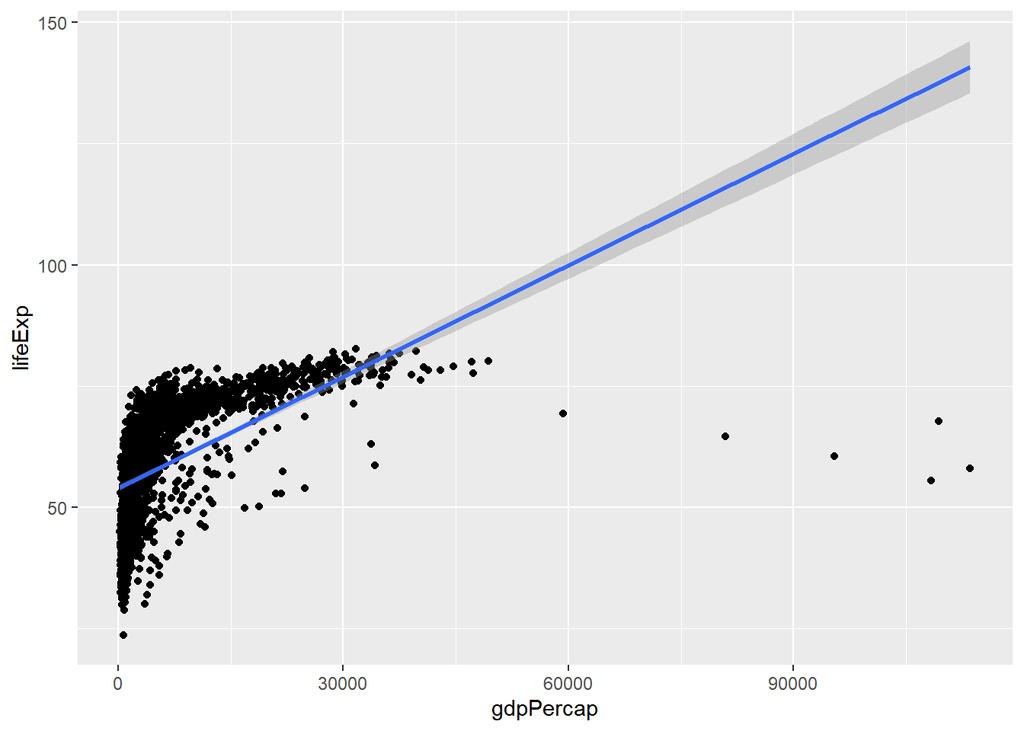

```r
p + geom_point() + geom_smooth(method = "lm")
```

로그 스케일 추가

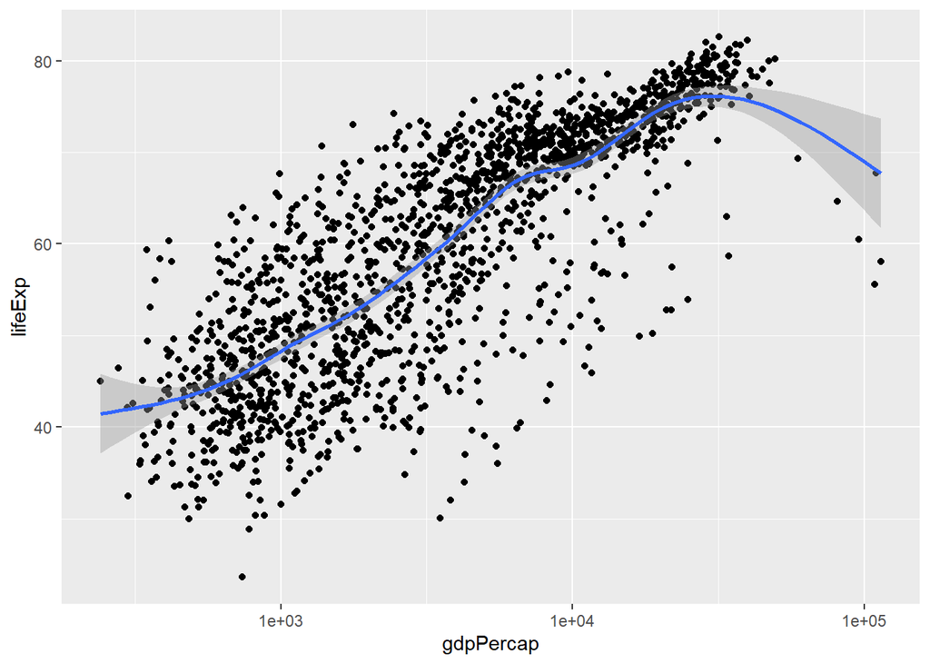

```r
p <- ggplot(data = gapminder,
            mapping = aes(x = gdpPercap,
                          y = lifeExp))

p + geom_point() +
    geom_smooth(method = "gam") +
    scale_x_log10()
```

x축을 $로 표시하기

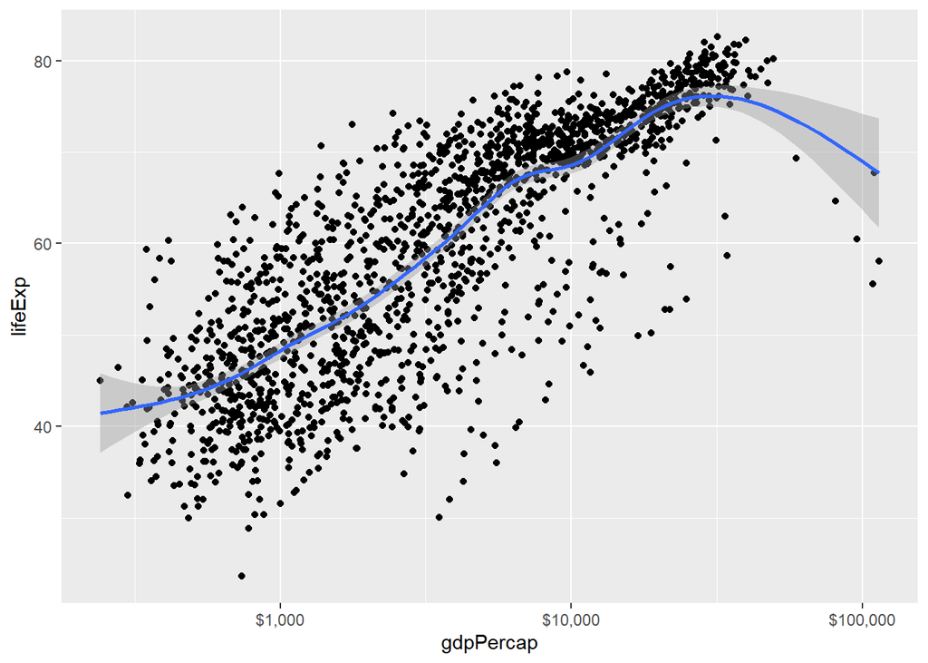

```r
p <- ggplot(data = gapminder,
            mapping = aes(x = gdpPercap,
                          y = lifeExp))

p + geom_point() +
    geom_smooth(method = "gam") +
    scale_x_log10(labels = scales::dollar)
```

### 3.5 미적 요소 매핑과 설정하기

미적 요소 매핑은 변수를 크기, 색상, 모양처럼 시각 요소 중 하나로 표현하도록 정해줌 변수는 아래와 같이 미적 요소에 매핑함

```r
p <- ggplot(data = gapminder,
            mapping = aes(x = gdpPercap,
                          y = lifeExp,
                          color = continent))
```

위의 코드는 “변수 continent를 속성 ’color’로 나타내라” 또는 “continent에 색상이 매핑될 것이다”와 같은 정보를 제공한다.

실제로 그래프를 그리면 대륙별로 다른 컬러와 평활 곡선이 나타나는 것을 확인할 수 있다.

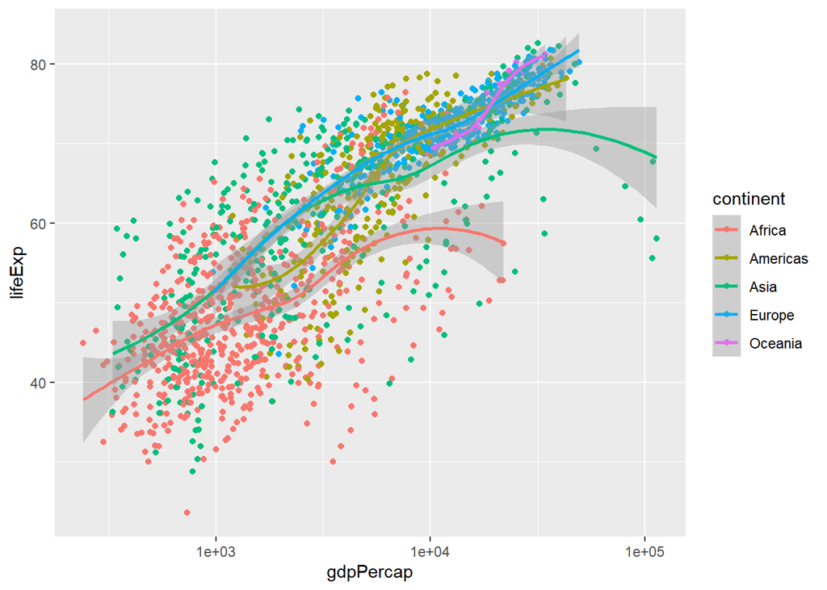

```r
p <- ggplot(data = gapminder,
            mapping = aes(x = gdpPercap,
                          y = lifeExp,
                          color = continent))

p + geom_point() + geom_smooth(method = "loess") + scale_x_log10()
```

만약 color를 “purple”로 놓는다면?

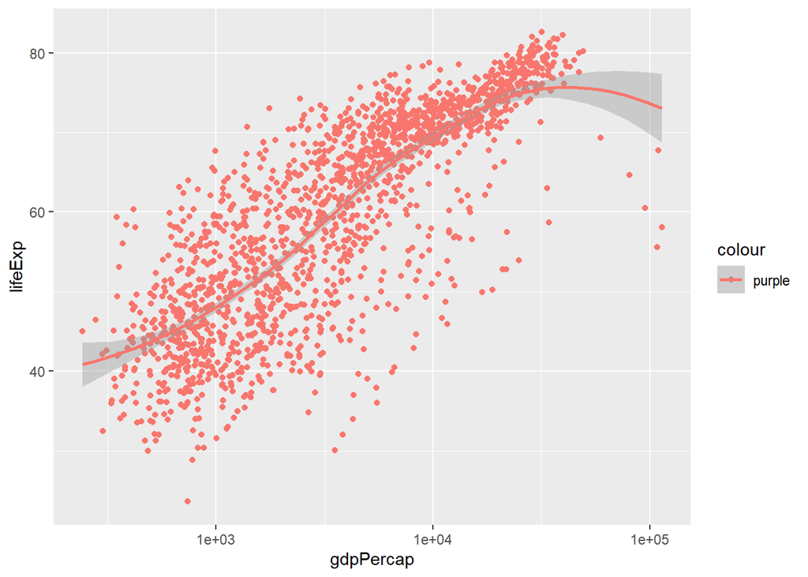

```r
p <- ggplot(data = gapminder,
            mapping = aes(x = gdpPercap,
                          y = lifeExp,
                          color = "purple"))

p + geom_point() + geom_smooth(method = "loess") + scale_x_log10()
```

컬러를 “purple”로 지정하면 색상을 보라색으로 넣는 것이 아니라 purple이라는 카테고리를 만들고 색상 파레트의 첫 번째 색상인 빨간색이 지정됨

aes() 함수는 매핑에만 사용된다는 점에 유의!

속성 값을 설정하려면 우리가 사용하는 geom_과 mapping = aes(…) 단계의 바깥에서 진행

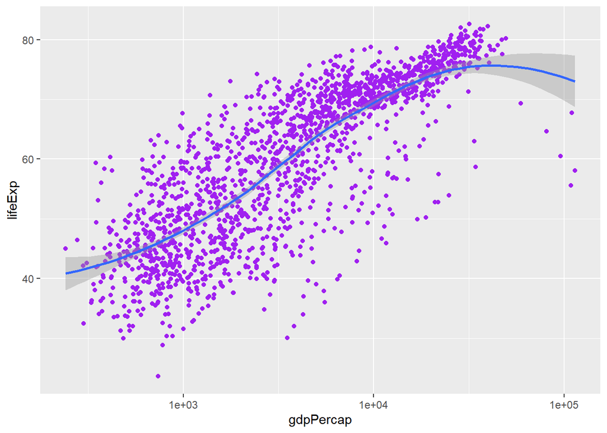

```r
p <- ggplot(data = gapminder,
            mapping = aes(x = gdpPercap,
                          y = lifeExp))
p + geom_point(color = "purple") + geom_smooth(method = "loess") +
  scale_x_log10()
```

위와 같이 점의 색상 속성을 직접 설정할 수 있음

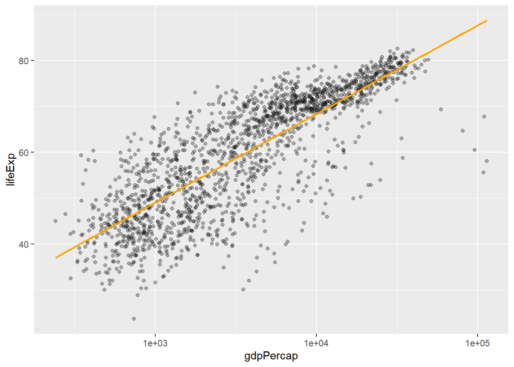

```r
p <- ggplot(data = gapminder,
            mapping = aes(x = gdpPercap,
                          y = lifeExp))

p + geom_point(alpha = 0.3) +
    geom_smooth(color = "orange",
                se = FALSE,
                size = 1,
                method = "lm") +
    scale_x_log10()
```

alpha는 투명도를 설정하는 인수로 0 ~ 1로 설정할 수 있다.

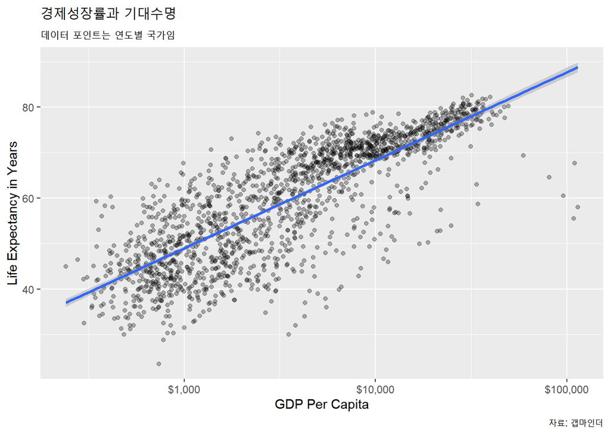

```r
p <- ggplot(data = gapminder,
            mapping = aes(x = gdpPercap,
                          y = lifeExp))

p + geom_point(alpha = 0.3) + geom_smooth(method = "lm") +
    scale_x_log10(labels = scales::dollar) +
    labs(x = "GDP Per Capita",
         y = "Life Expectancy in Years",
         title = "경제성장률과 기대수명",
         subtitle = "데이터 포인트는 연도별 국가임",
         caption = "자료: 갭마인더")
```

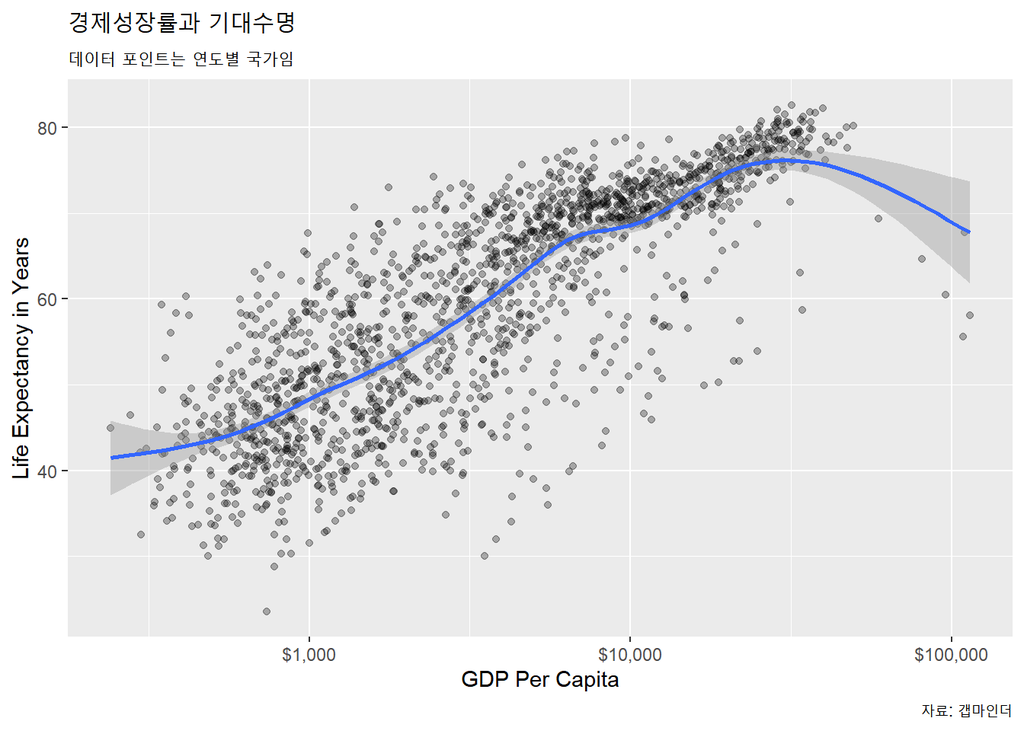

```r
p <- ggplot(data = gapminder,
            mapping = aes(x = gdpPercap,
                          y = lifeExp))

p + geom_point(alpha = 0.3) + geom_smooth(method = "gam") +
    scale_x_log10(labels = scales::dollar) +
    labs(x = "GDP Per Capita",
         y = "Life Expectancy in Years",
         title = "경제성장률과 기대수명",
         subtitle = "데이터 포인트는 연도별 국가임",
         caption = "자료: 갭마인더")
```

labs() 함수는 x축 라벨, y축 라벨, 표제, 부제, 캡션 등을 설정할 수 있다.

만약 geom 함수에 다른 지시사항이 없다면 원래 객체에 포함된 geom의 매핑 속성이 모두 상속된다.

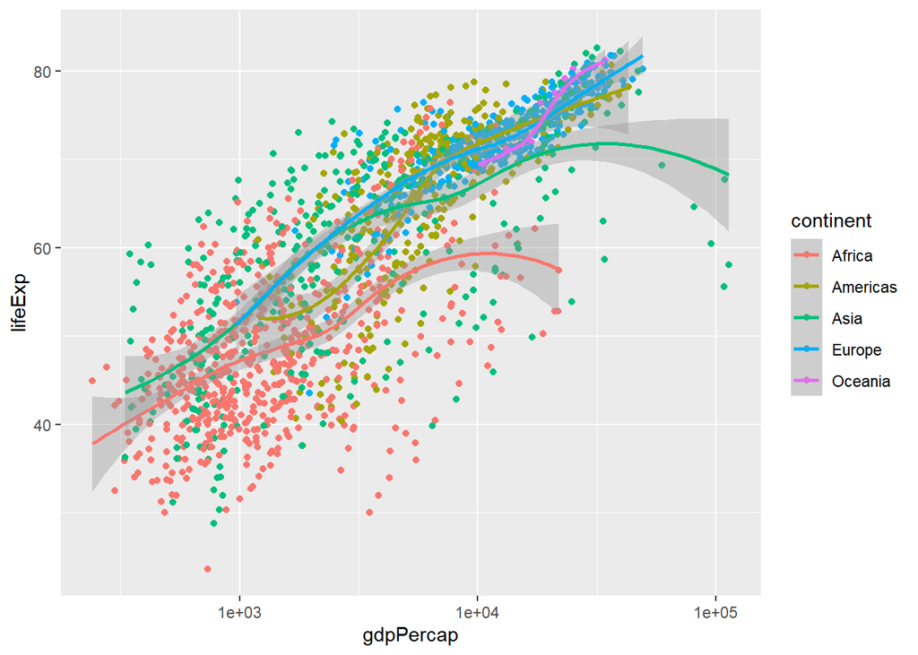

```r
p <- ggplot(data = gapminder,
            mapping = aes(x = gdpPercap,
                          y = lifeExp,
                          color = continent))

p + geom_point() + geom_smooth(method = "loess") +
    scale_x_log10()
```

원한다면 각 선의 표준오차 리본을 주조색(dominant color)과 일치하도록 음영 처리할 수 있음 (미적 요소 aes의 fill을 통해 실행) - color가 선과 점의 외관에 영향을 미치는 반면, - fill은 막대와 다각형의 채워진 영역, 평활기(smoother)의 표준오차 리본 내부를 채우는 것

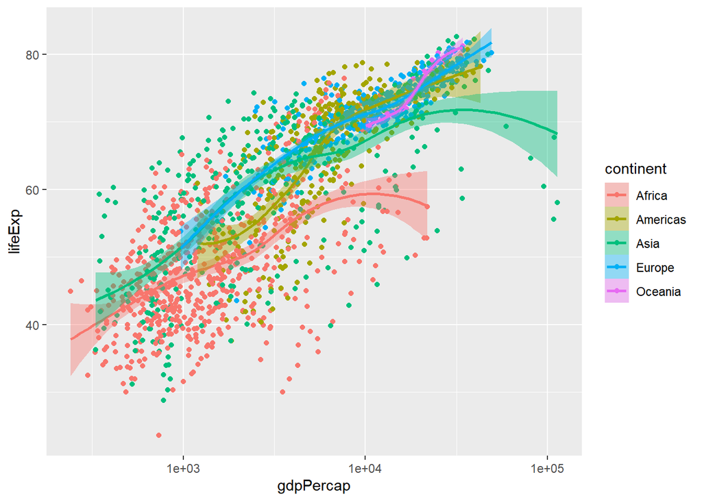

```r
p <- ggplot(data = gapminder,
            mapping = aes(x = gdpPercap,
                          y = lifeExp,
                          color = continent,
                          fill = continent))

p + geom_point() + geom_smooth(method = "loess") +
    scale_x_log10()
```

### 3.6 미적특질은 geom마다 매핑될 수 있다.

- 만약 추체선은 한 개, 점은 대륙별로 색상을 달리하고 싶다면?

기본적으로 geom()은 ggplot() 함수에서 기존 매핑을 상속받는데, 각 geom 마다 미적 특징(aesthetics)을 달리할 수 있다. (geom_ 함수도 활용해서 각각 적용하려는 매핑을 명시)

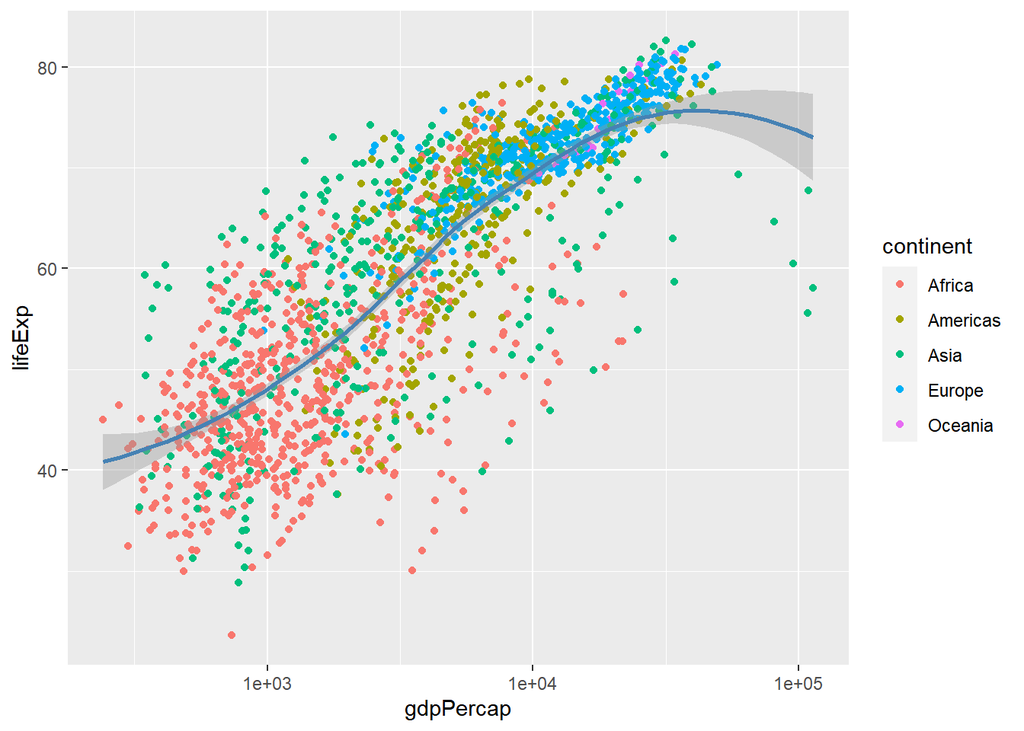

```r
p <- ggplot(data = gapminder,
            mapping = aes(x = gdpPercap,
                          y = lifeExp))
p + geom_point(mapping = aes(color = continent)) +
    geom_smooth(method = "loess",
                color = "steelblue") +
    scale_x_log10()
```

연속형 변수도 color에 매핑할 수 있다.

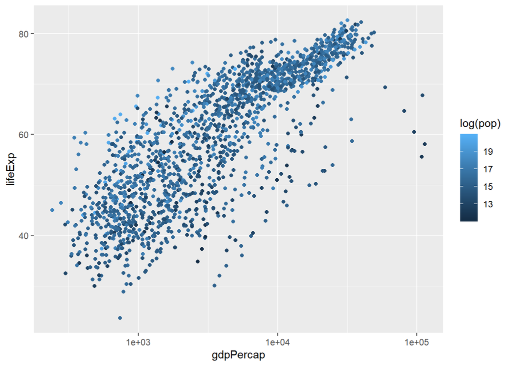

```r
p <- ggplot(data = gapminder,
            mapping = aes(x = gdpPercap,
                          y = lifeExp))

p + geom_point(mapping = aes(color = log(pop))) + scale_x_log10()
```

### 3.7 작업 저장하기

코드 청크 옵션을 통해 도표의 크기 설정

```r
# knitr::opts_chunk$set(fig.width = 8, fig.height = 5)
```

특정 청크에 동일한 옵션을 넣을 수도 있음

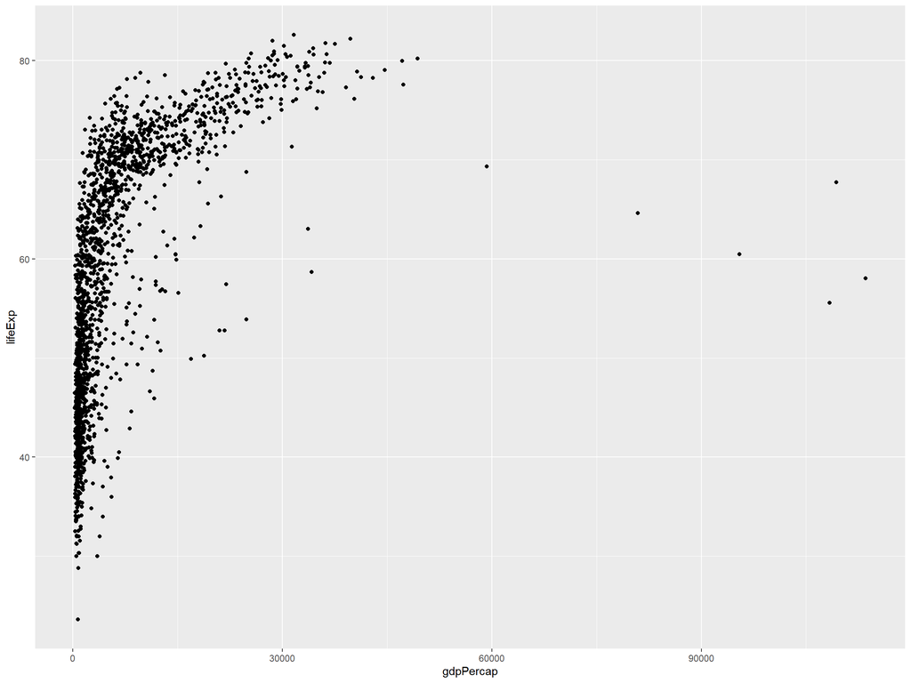

```r
p + geom_point()
```

R마크다운으로 작성하지 않은 문서나 논문에 삽입하는 이미지는 따로 저장해둬야 함

- ggplot으로 작업할 때는 ggsave() 함수를 사용하면 가장 쉬움

```r
# ggsave(filename = "my_figure.png")
```

- 플롯 객체를 ggsave()에 전달 가능

```r
p_out <- p + geom_point() + geom_smooth(method = "loess") +
             scale_x_log10()

ggsave("my_figure.pdf", plot = p_out)
```

here() 함수를 사용해 작업을 좀 더 간단하고 안전하게 저장하고 불러올 수 있다.

```r
library(here)
```

```r
ggsave(here("figures", "lifeexp_vs_gdp_gradient.pdf"), plot = p_out)
```

## 정리

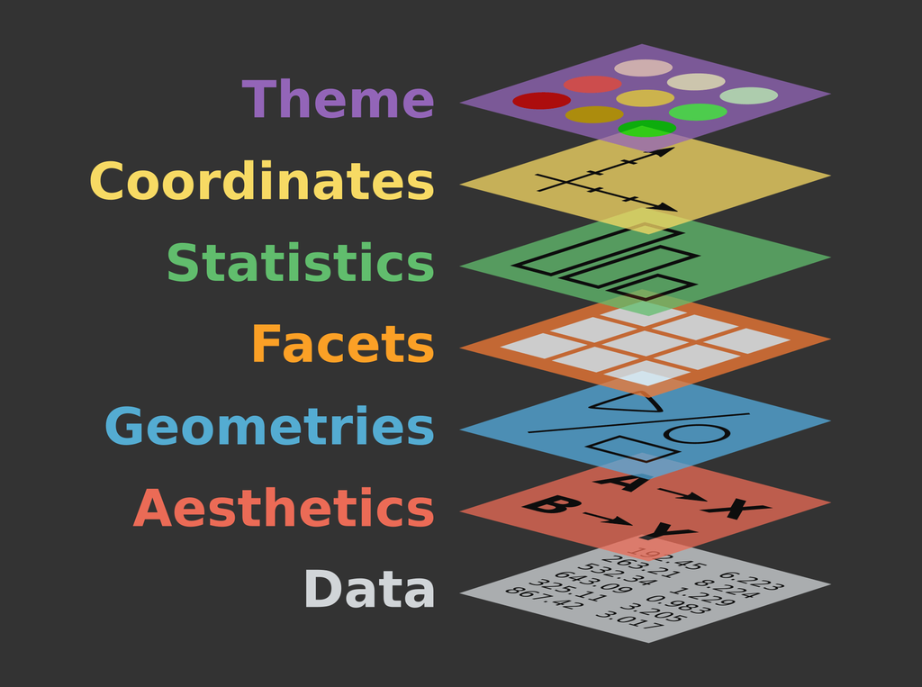

## Basic Requirements to generate a ggplot

```
ggplot(data = <DATA>) +

  <GEOM function> (mapping = aes(<mappings),
                   stat = <STAT>,
                   position = <POSITION>) +

  <COORDINATE function> +
  <SCALE function> +
  <THEME function> +
  <FACET function> + ...
```

- Data
  - 정돈된 포맷(tidy format) 필요
  - `dplyr` 이용 준비
- Aesthetics
  - `x`, `y`: x축과 y축 변수 설정
  - `colour` : 기하적 구조의 색상 설정
  - `fill` : 기하적 구조 안에 채우는 색상 설정
  - `group` : 기하적 구조를 구분짓는 그룹 설정
  - `shape` : 점의 형태
  - `linetype` : 선의 형태
  - `size` : x축과 y축 이외의 기타 차원(extra dimension)의 스케일링 지정
  - `alpha` : 기하적 구조의 투명도
- Geometric objects
  - `geom_point()`: 스캐터 플랏(scatter plot)
  - `geom_line()`: 라인 플랏
  - `geom_path()`: 순차적으로 데이터를 연결하는 선을 그리는 플랏
  - `geom_boxplot()`: 카테고리별 변수에 대한 박스플랏
  - `geom_bar()`: 카테고리별 변수 x에 대한 바 차트
  - `geom_histogram()`: 연속형 변수 x에 대한 히스토그램
  - `geom_violin()`: 데이터 분산에 대한 커널 분포를 박스플랏처럼 나타낸 플랏
  - `geom_smooth()`: 평활화한 플랏
- Facets
  - `facet_wrap()` or `facet_grid()`: 다중 그래프 생성
- Statistics
  - geom과 비슷하지만 계산이 필요
  - 평균, 카운트 및 요약통계량 표시
- Coordinates
  - `coord_cartesian`: 리밋 설정
  - `coord_polar`: 원형 플랏
  - `coord_map`: for different map projections
- Themes
  - 기본 설정 및 폰트, 색상, 아웃라인 등 설정